# Eurovision

[figure not shown]

[figure not shown]

[figure not shown]

[figure not shown]

[figure not shown]

[figure not shown]

# About

Eurovision is a popular music computation that includes many teams from all over Europe each representing their nation. It’s been on for several decades. The dataset consists info on all teams that have participated since 1951 and their rankings. More information about them can be found here. https://github.com/rfordatascience/tidytuesday/blob/master/data/2022/2022-05-17/readme.md

# Data

This is what the data looks like. The raw file can be downloaded from https://github.com/rfordatascience/tidytuesday/blob/master/data/2022/2022-05-17/eurovision.csv

|  | event | host_city | year | host_country | event_url | section | artist | song | artist_url | image_url | artist_country | country_emoji | running_order | total_points | rank | rank_ordinal | qualified | winner |
| --- | --- | --- | --- | --- | --- | --- | --- | --- | --- | --- | --- | --- | --- | --- | --- | --- | --- | --- |
| 1 | Turin 2022 | Turin | 2022 | Italy | https://eurovision.tv/event/turin-2022 | first-semi-final | Kalush Orchestra | Stefania | https://eurovision.tv/participant/kalush-orchestra-22 | https://static.eurovision.tv/hb-cgi/images/963164d0-060d-4667-96b6-0b0cf1f797e6/avatar_small.jpg | Ukraine | :flag_ua: | 6 | 337 | 1 | 1st | True | False |
| 2 | Turin 2022 | Turin | 2022 | Italy | https://eurovision.tv/event/turin-2022 | first-semi-final | S10 | De Diepte | https://eurovision.tv/participant/s10-22 | https://static.eurovision.tv/hb-cgi/images/96316719-75b2-415a-a60d-1c2dbdbd7eee/avatar_small.jpg | Netherlands | :flag_nl: | 8 | 221 | 2 | 2nd | True | False |
| 3 | Turin 2022 | Turin | 2022 | Italy | https://eurovision.tv/event/turin-2022 | first-semi-final | Amanda Georgiadi Tenfjord | Die Together | https://eurovision.tv/participant/amanda-georgiadi-tenfjord-22 | https://static.eurovision.tv/hb-cgi/images/9633696f-e238-4d32-8c27-c99ee0cecb6c/avatar_small.jpg | Greece | :flag_gr: | 15 | 211 | 3 | 3rd | True | False |
| 4 | Turin 2022 | Turin | 2022 | Italy | https://eurovision.tv/event/turin-2022 | first-semi-final | MARO | Saudade, Saudade | https://eurovision.tv/participant/maro-22 | https://static.eurovision.tv/hb-cgi/images/96336bae-9891-466a-b723-a3281c80f61d/avatar_small.jpg | Portugal | :flag_pt: | 10 | 208 | 4 | 4th | True | False |
| 5 | Turin 2022 | Turin | 2022 | Italy | https://eurovision.tv/event/turin-2022 | first-semi-final | Intelligent Music Project | Intention | https://eurovision.tv/participant/intelligent-music-project-22 | https://static.eurovision.tv/hb-cgi/images/963166b3-81d6-409e-8a0a-12c176e1156d/avatar_small.jpg | Bulgaria | :flag_bg: | 7 | 29 | 16 | 16th | False | False |
| 6 | Turin 2022 | Turin | 2022 | Italy | https://eurovision.tv/event/turin-2022 | first-semi-final | LPS | Disko | https://eurovision.tv/participant/lps-22 | https://static.eurovision.tv/hb-cgi/images/96316379-9142-4117-a56c-bffa8aaf1011/avatar_small.jpg | Slovenia | :flag_si: | 5 | 15 | 17 | 17th | False | False |
| 7 | Turin 2022 | Turin | 2022 | Italy | https://eurovision.tv/event/turin-2022 | first-semi-final | Rosa Linn | Snap | https://eurovision.tv/participant/rosa-linn-22 | https://static.eurovision.tv/hb-cgi/images/96336d8d-6b40-42b1-b25f-f99eafffc244/avatar_small.jpg | Armenia | :flag_am: | 17 | 187 | 5 | 5th | True | False |
| 8 | Turin 2022 | Turin | 2022 | Italy | https://eurovision.tv/event/turin-2022 | first-semi-final | Subwoolfer | Give That Wolf A Banana | https://eurovision.tv/participant/subwoolfer-22 | https://static.eurovision.tv/hb-cgi/images/96336df0-62dc-45a6-85ed-84ad27da5f3d/avatar_small.jpg | Norway | :flag_no: | 16 | 177 | 6 | 6th | True | False |
| 9 | Turin 2022 | Turin | 2022 | Italy | https://eurovision.tv/event/turin-2022 | first-semi-final | Monika Liu | Sentimentai | https://eurovision.tv/participant/monika-liu-22 | https://static.eurovision.tv/hb-cgi/images/96301c95-81f1-444c-a503-b7dad4df419b/avatar_small.jpg | Lithuania | :flag_lt: | 3 | 159 | 7 | 7th | True | False |
| 10 | Turin 2022 | Turin | 2022 | Italy | https://eurovision.tv/event/turin-2022 | first-semi-final | Zdob şi Zdub &amp; Advahov Brothers | Trenulețul | https://eurovision.tv/participant/zdob-si-zdub-and-fratii-advahov-22 | https://static.eurovision.tv/hb-cgi/images/96318be3-1473-4ad6-8270-e18043886fd9/avatar_small.jpg | Moldova | :flag_md: | 9 | 154 | 8 | 8th | True | False |

[output cut: 90 more lines]

# Static 1

### First chart

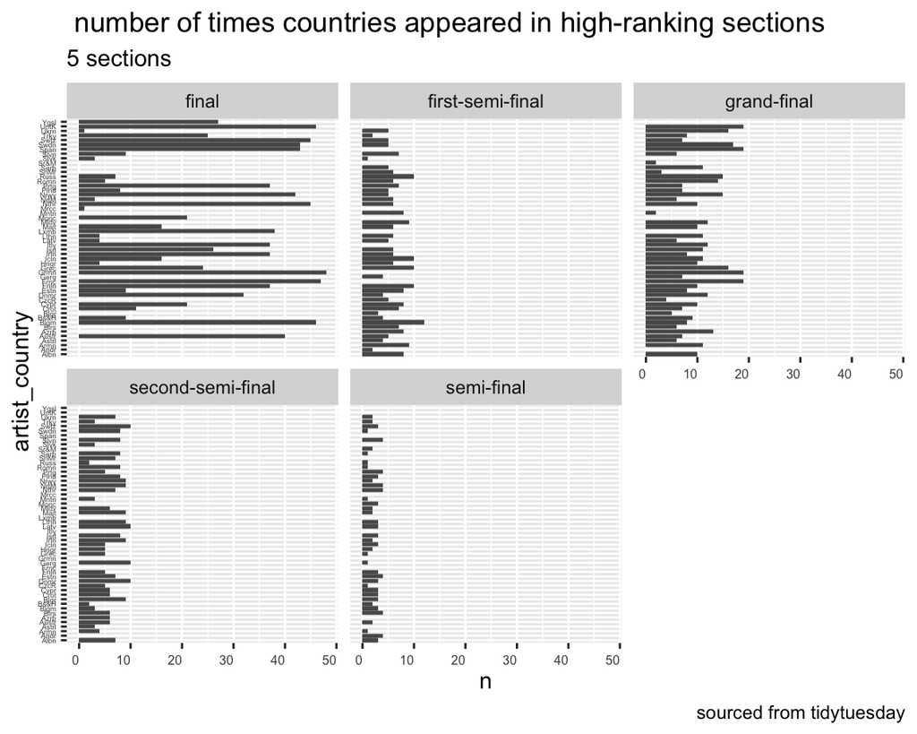

# Static 2

### Chart 2

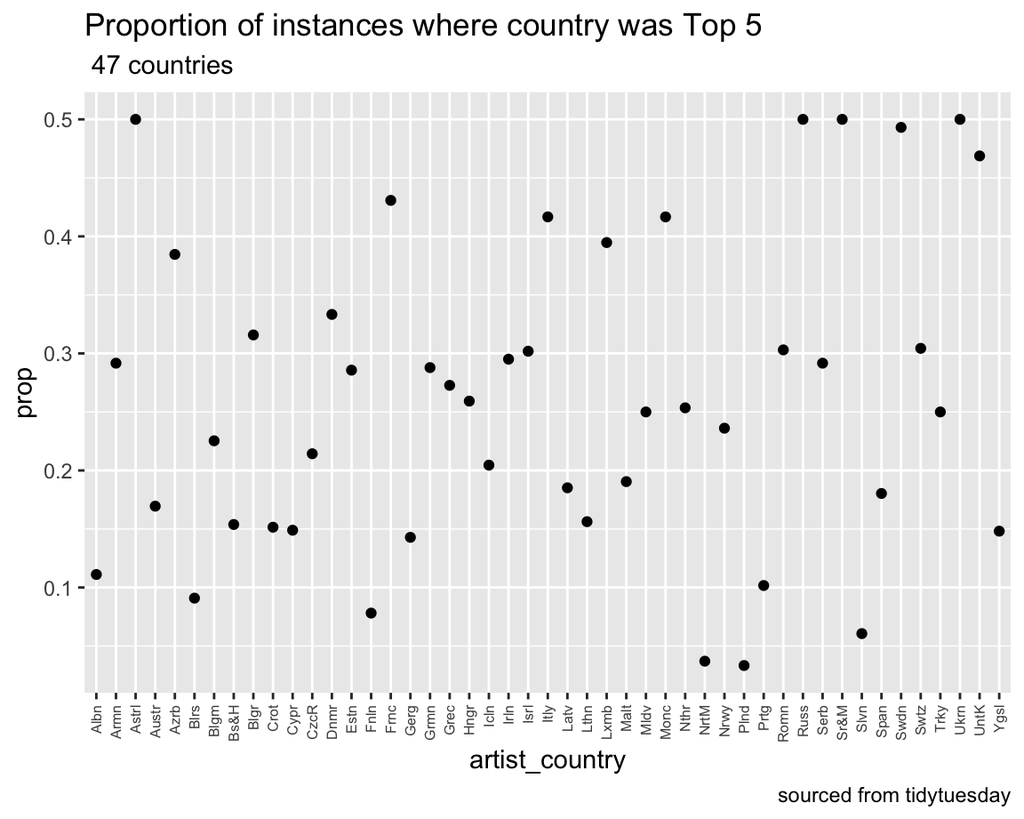

### Chart 3

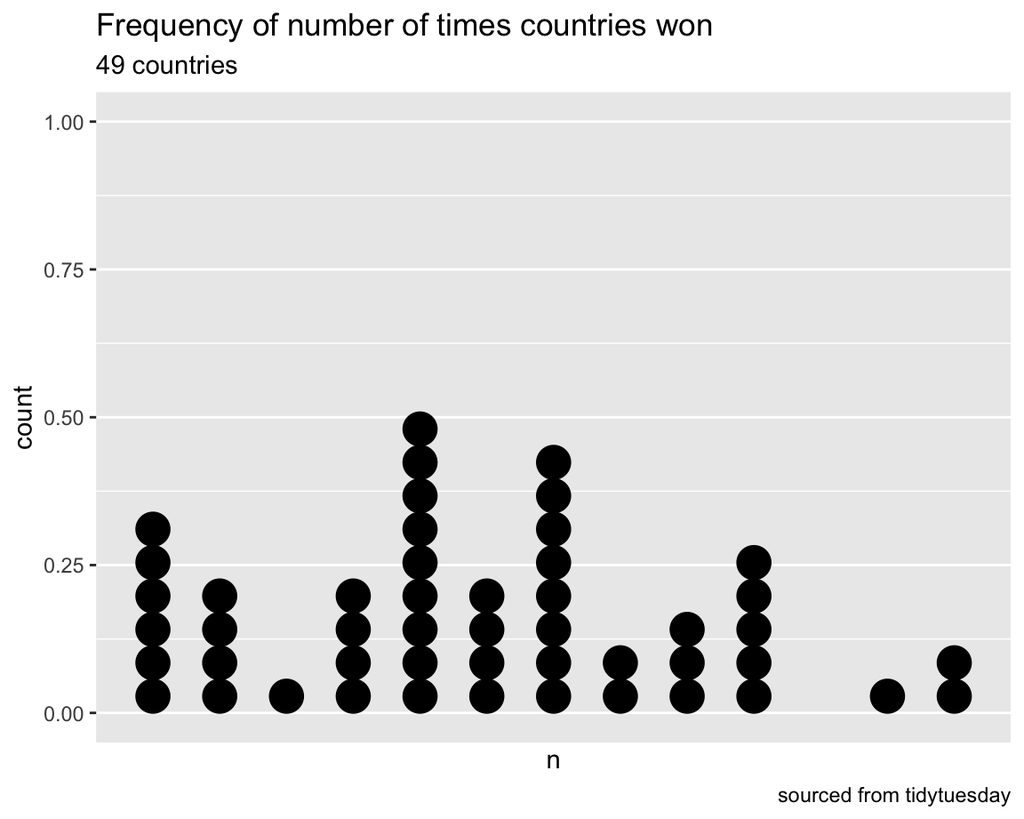